# Linear Regression Models with Categorical Predictors

Cheng Peng

STA200 Statistics II

# 1 Introduction

We have briefly introduced the simple linear regression model earlier with an explicit expression.

$$y = \beta_0 + \beta_1 x + \epsilon,$$

Where $y$ is a continuous random numerical variable, $x$ is either a numerical variable or a binary categorical variable, and $\epsilon \rightarrow N(0, \sigma)$, the basic applications of a simple linear regression model are twofold:

1. **Assess** the linear correlation between the response variable ($y$) and the predictor variable ($x$).
2. **Predict** the response for given new values of the predictor variable $x$.

In general, regression modeling is an iterative process in real-world applications, as illustrated in the following chart.

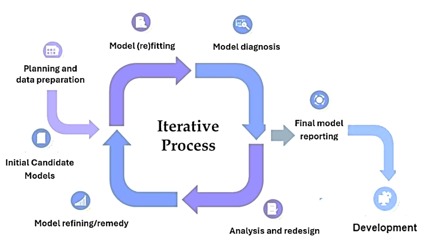

In the course project and data analysis, we focus on the iterative loop of model identification and reporting on the final model. To be more specific, assuming we have an analytic data set that is ready for modeling,

- **Select appropriate candidate models to address the practical questions** - This includes checking model assumptions and ensuring the analytic dataset contains sufficient information for the candidate models. *We have highlighted all assumptions when introducing new models in the previous notes.*
- **Fit candidate models to the data** - This step involves verifying the outputs to ensure the model parameters (e.g., coefficients) are appropriately estimated.

> **Note:** *the fitted models in this step may not be valid or optimal, we should not interpret the model at this point.* **We only report the final model obtained from the iterative model identification process.**
- **Model diagnostics** - This is the most crucial step in any regression analysis, where we assess whether all assumptions of the candidate models are satisfied. For example, we apply residual diagnostic methods (commonly used in linear regression) to evaluate linearity, normality, homoscedasticity (constant variance), and other key assumptions. If no violations are detected, we then use application-specific performance measures to select the best model for reporting and implementation.
- **Model remedy and refinement** - If one or more assumptions are violated, we need to use various methods to fix the problems. *We will not discuss this major topic in this class, but will cover this critical topic in detail in subsequent courses*.
- **Enter the refined/modified model into the loop for the next iteration** - The refined or modified model will be refitted, analyzed, and diagnosed to determine whether any violations remain. This process continues iteratively until the final valid and optimal model is identified.
- **Final model reporting** - This topic will not be emphasized in this class but will be highlighted in subsequent statistical modeling classes.

In this note, we will extend simple linear regression to multiple linear regression by incorporating two or more predictor variables into the model. We begin by revisiting the simple linear regression model discussed earlier this semester. Next, we will generalize the binary categorical predictor to multi-category predictors through the use of binary indicator variables – effectively creating a special case of multiple linear regression with multiple binary categorical variables. This approach integrates ANOVA analysis into the regression framework.

# 2 Simple Linear Regression Revisited

The term **simple linear regression** (SLR) simply means that the regression equation has the form $y = \beta_0 + \beta_1 x + \epsilon$. The predictor variable is either a continuous variable or a binary categorical variable that takes only two possible distinct values, such as *success* vs *failure*, *disease* vs *disease-free*, etc. **The response must be a continuous normal variable whose mean may be influenced by the predictor $x$ but not the variance.**

The key assumptions for SLR are

- **linearity**: linear relationship between $y$ and $x$;
  - diagnostic check: scatter plot of $x$ and $y$
- **deterministic predictor $x$**: the predictor variable is not a random variable.
  - No direct information, check this assumption
- **normality**: the only random variable $y$ is a normal random variable with density function $N(\beta+0 + \beta_1 x, \sigma)$, or $\epsilon \rightarrow N(0, \sigma)$.
  - diagnostic check: Q-Q plot
- **constant variance**: this assumption is contained in the above **normality** assumption.
  - diagnostic check: residual plot, studentized residual plot
- **Influential observations**: This is also related to the **normality assumption**
  - diagnostic check: leverage plot (Cook’s distance)

## 2.1 SLR with A Continuous Predictor

When the predictor variable is continuous, the interpretation of the slope $\beta_1$ reflects the change in $y$ when $x$ increases by one unit. The sign of $\beta_1$ reflects the direction of linear association between $x$ and $y$. Next, we use a numerical example to illustrate the regression modeling process. The data set can be found at https://pengdsci.github.io/STA200/dataset/EduWage.csv. The R function `lm()` will be used to perform regression analysis.

The variables in the data set are defined as

- **wage**: average hourly earnings
- **educ**: years of education
- **exper**: years potential experience
- **tenure**: years with current employer
- **lwage**: log(wage) - in economics, it is called log wage.
- **region**: the geographic region of the respondent
- **smsa**: A Standard Metropolitan Statistical Area (SMSA) is a geographical region defined by the U.S. Office of Management and Budget that consists of a core urban area with a substantial population, along with adjacent communities that have a high degree of economic and social integration with that core. SMSAs are used for statistical purposes to analyze urbanization, population density, and economic activities in metropolitan areas, providing insights into urban data trends.

**Step 1**: Load data and explore the dataset.

```r
## Load the dataset
edu.wage <- read.csv("https://pengdsci.github.io/STA200/dataset/EduWage.csv")
## summary of variables in the dataset
summary(edu.wage)
```

```
|       wage             educ           exper           tenure
|  Min.   : 0.530   Min.   : 0.00   Min.   : 1.00   Min.   : 0.000
|  1st Qu.: 3.330   1st Qu.:12.00   1st Qu.: 5.00   1st Qu.: 0.000
|  Median : 4.650   Median :12.00   Median :13.50   Median : 2.000
|  Mean   : 5.896   Mean   :12.56   Mean   :17.02   Mean   : 5.105
|  3rd Qu.: 6.880   3rd Qu.:14.00   3rd Qu.:26.00   3rd Qu.: 7.000
|  Max.   :24.980   Max.   :18.00   Max.   :51.00   Max.   :44.000
|      lwage            region               smsa
|  Min.   :-0.6349   Length:526         Min.   :0.0000
|  1st Qu.: 1.2030   Class :character   1st Qu.:0.0000
|  Median : 1.5369   Mode  :character   Median :1.0000
|  Mean   : 1.6233                      Mean   :0.7224
|  3rd Qu.: 1.9286                      3rd Qu.:1.0000
|  Max.   : 3.2181                      Max.   :1.0000
```

The R function `summary(dataset.name)` returns a five-number summary of all numerical variables in the dataset. There is a categorical variable `region` in the dataset. To see the distribution of **categorical variables**, we use the R function `table(variable.name)` to see the frequency distribution of the categorical variables.

```r
table(edu.wage$region)
```

```
| northcen    other    south     west
|      132      118      187       89
```

**Step 2**: objective and candidate model - we examine whether education affects the wage. The candidate model to address this objective will be the simple linear regression model. We first make a scatter plot of `educ` (horizontal axis) and `wage` (vertical axis).

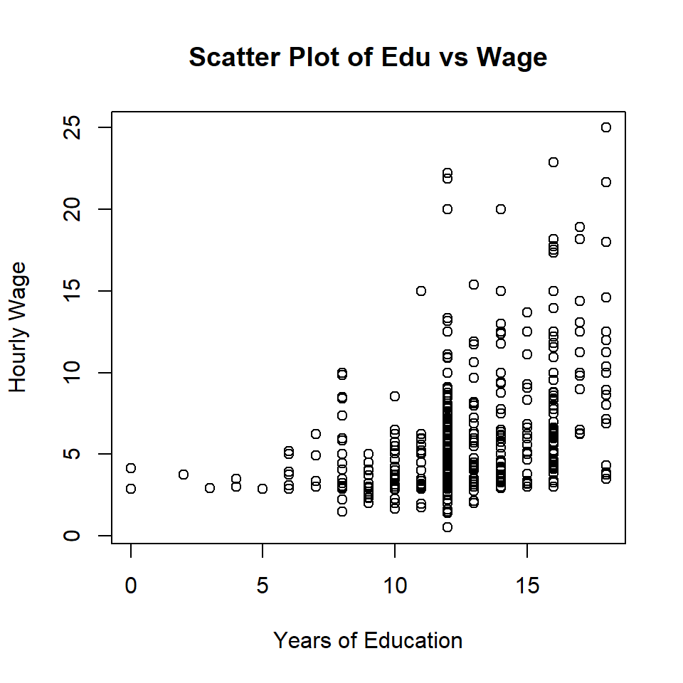

```r
plot(edu.wage$educ,                 # horizontal axis
     edu.wage$wage,                 # vertical axis
     xlab = "Years of Education",   # horizontal label
     ylab = "Hourly Wage",          # vertical label
     main = "Scatter Plot of Edu vs Wage"    # title of the plot
     )
```

The above plot shows a linear relationship but also shows non-constant variance. This violates the SLR assumption. Economic studies show that logarithmic wage has less variation. We next try to log wages in the SLR. Before building the model, we make a scatter plot of log wage vs years of education.

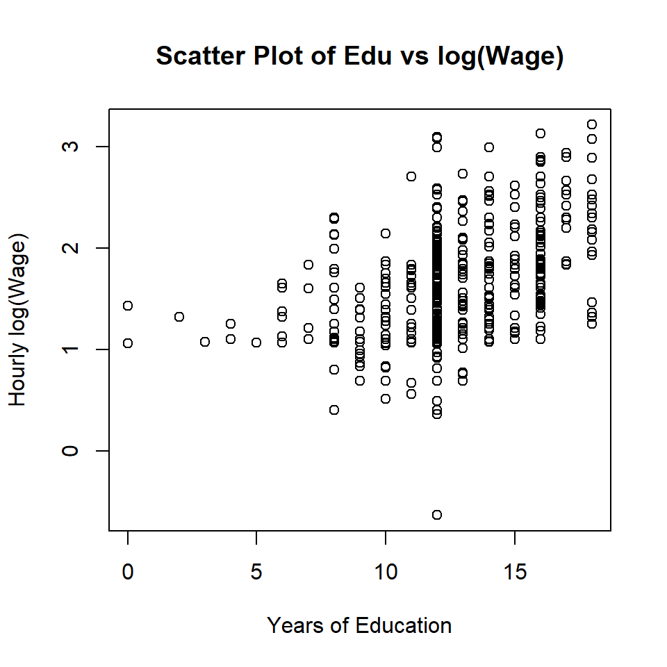

```r
plot((edu.wage$educ)[-1],                 # horizontal axis
     (edu.wage$lwage)[-1],                 # vertical axis
     xlab = "Years of Education",   # horizontal label
     ylab = "Hourly log(Wage)",          # vertical label
     main = "Scatter Plot of Edu vs log(Wage)"    # title of the plot
     )
```

The above scatter indicates that the log wage is a better response for SLR.

**Step 3**: Fitting SLR: $\text{log wage} = \beta_0 + \beta_1 \text{educ}$ and perform residual diagnostics.

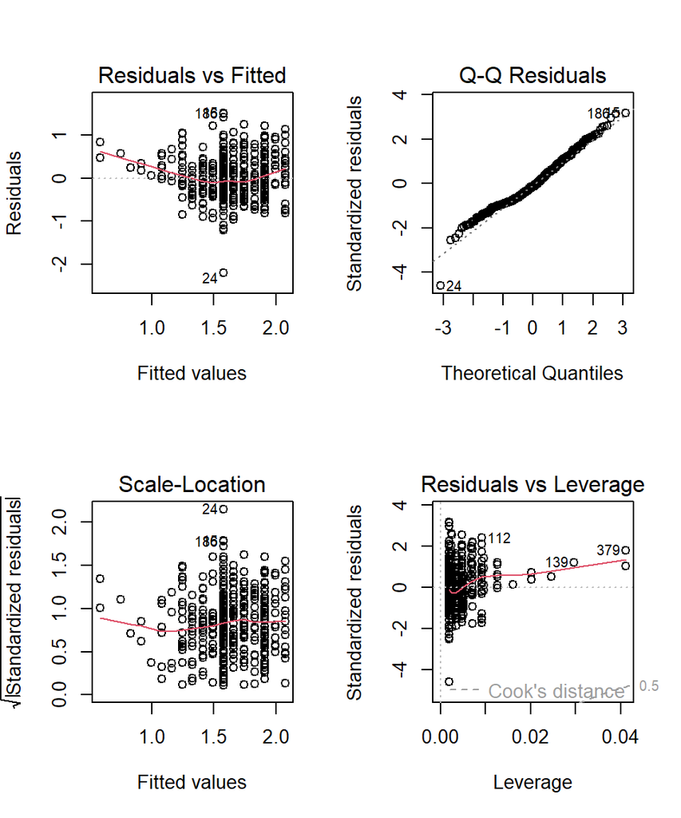

```r
## linear model
lgw.model <- lm(lwage ~ educ, data = edu.wage)
## residual plot
par(mfrow=c(2,2))    # create a graphic grid with 4 graphical cells
plot(lgw.model)
```

Interpretations of Residual Diagnostic Plots:

- **Residual vs Fitted** - shows a minor violation of the assumption of constant variance (the variance increases as the fitted value increases)
- **Q_Q Residual Plot** - There is no significant violation of the normal distribution
- **Scale-Location Plot** - no serious violation except a few outliers (not influential)
- **Residuals-Leverage** - shows no influential points.

Overall, there is a minor violation of the constant variance assumption. We will learn methods in subsequent courses to refine the model. For illustration, we decided to report the above model.

**Step 4** - summarize the log wage model

```r
summary(lgw.model)
```

```
| Call:
| lm(formula = lwage ~ educ, data = edu.wage)
| Residuals:
|      Min       1Q   Median       3Q      Max
| -2.21158 -0.36393 -0.07263  0.29712  1.52339
| Coefficients:
|             Estimate Std. Error t value Pr(>|t|)
| (Intercept) 0.583773   0.097336   5.998 3.74e-09 ***
| educ        0.082744   0.007567  10.935  < 2e-16 ***
| ---
| Signif. codes:  0 '***' 0.001 '**' 0.01 '*' 0.05 '.' 0.1 ' ' 1
| Residual standard error: 0.4801 on 524 degrees of freedom
| Multiple R-squared:  0.1858,  Adjusted R-squared:  0.1843
| F-statistic: 119.6 on 1 and 524 DF,  p-value: < 2.2e-16
```

**Brief Report**:

The estimated slope coefficient $\hat{\beta}_1 = 0.082744$ indicates that log wage increases by 0.082744 for each additional year of education ($p \approx 0$). The coefficient of determination $R^2 \approx 0.1858$ shows that the log wage and years of education have a weak linear correlation.

**Remarks**: Here are a few comments on the general principles of regression analysis

- In this example, we use only two variables in the data set with more than 2 variables to illustrate how to implement an SLR. In practice, if you have more information (more variables) available in the data, we should use all relevant information - **this is the general principle of all data analysis**. This means we need to use multiple regression to include two or more predictor variables! We will cover general MLR in the next note.
- **Implication of SLR**: An implication of SLR is that all other variables do not affect the response variable $y$. This also implies that, in general, an SLR can never be an optimal model if it is invalid.
- **Choose an optimal subset of predictors**: This means we always start with multiple candidate models in multiple linear regression (MLR) models. For example, if we have two variables $x_1$ and $x_2$, we can fit three different **first order** (in predictor variables) MLR based on the combinations of $x_1$, $x_2$, and $x_1 + x_2$. More on different MLRs will be discussed in the next note.

## 2.2 SLR with A Binary Predictor

We have discussed the regression approach to the two-sample t-test at the beginning of the semester. Here we use the sample wage dataset and a binary categorical `smsa`(Standard Metropolitan Statistical Area) to see whether the average wage in **rural** and **urban** areas is different.

Recall the assumption in the two-sample test:

- Wage distributions in both populations (rural and urban populations) are normal, equivalent to the **normality assumption** on SLR
- The variances of wages in both populations are unknown but equal, equivalent to the **constant variance assumption** in SLR.

When using a software program, we have to specify the predictor variable $x$ to be a factor (categorical variable). In R, the function `factor()` converts a categorical or discrete numerical variable (with finite distinct values) to a factor variable.

We next implement the SLR with a binary factor variable (`smsa`) and use log wage `lwage` as the response.

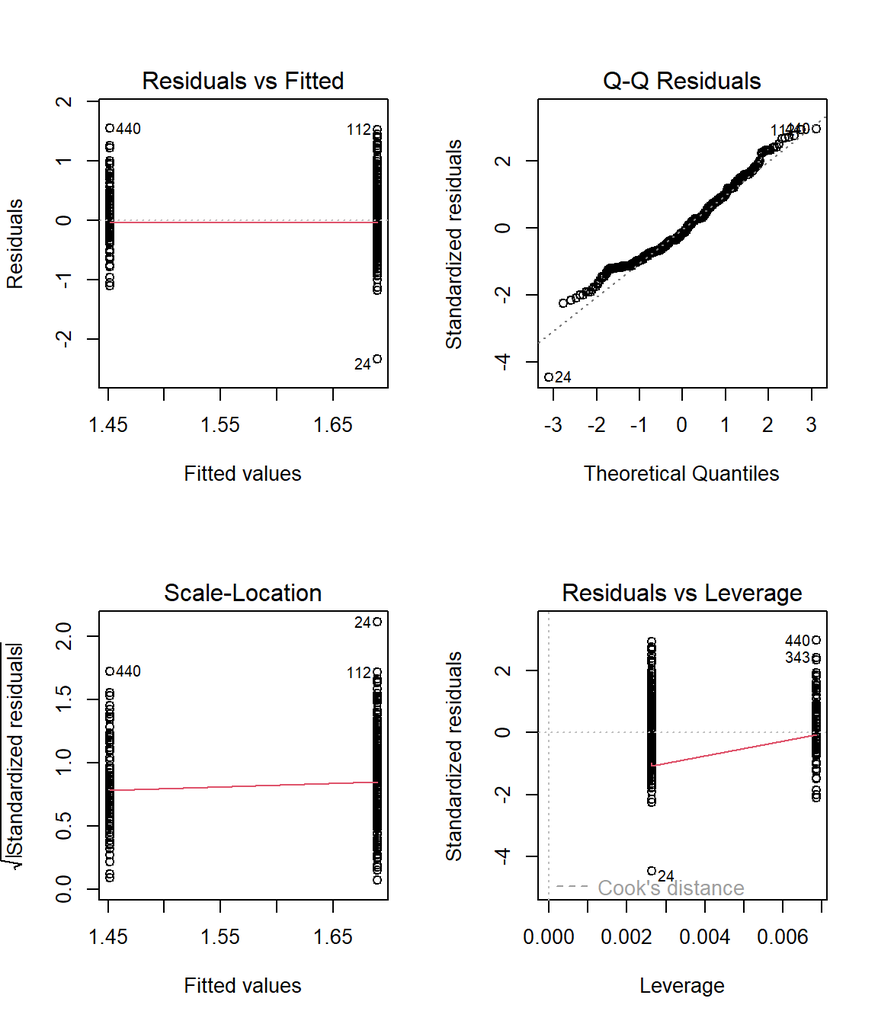

```r
# lm model
smsa.lm <- lm(lwage ~ factor(smsa), data = edu.wage)
# residual plots
par(mfrow=c(2,2))
plot(smsa.lm)
```

**1. Interpretations of Residual Diagnostic Plots**

- **Residual-fitted Values**: does not reveal special patterns. The variances of the two groups seem to be similar to each other.
- **Q-Q Plot**: No serious violation of the normality assumption was found from the Q-Q plot. Note that there is an outlier in the plot.
- **Scale-location Plot**: does not reveal any special pattern except for an outlier (obs N0. 24).
- **Residuals vs Leverage**: The Cook’s distance of observation does not have a significant leverage (no influential).

Overall, there is no significant violation of model assumptions. We report the current model in the following:

**2. Interpretations of Regression Coefficients**

The binary variable`smsa` has two values: 0 = rural area, 1 = urban area. In general, a binary variable (taking values 0 and 1) is also commonly called a **dummy variable** in statistics and regression analysis.

```r
summary(smsa.lm)
```

```
| Call:
| lm(formula = lwage ~ factor(smsa), data = edu.wage)
| Residuals:
|     Min      1Q  Median      3Q     Max
| -2.3240 -0.3700 -0.0797  0.3422  1.5439
| Coefficients:
|               Estimate Std. Error t value Pr(>|t|)
| (Intercept)    1.45182    0.04314  33.652  < 2e-16 ***
| factor(smsa)1  0.23732    0.05076   4.676 3.73e-06 ***
| ---
| Signif. codes:  0 '***' 0.001 '**' 0.01 '*' 0.05 '.' 0.1 ' ' 1
| Residual standard error: 0.5213 on 524 degrees of freedom
| Multiple R-squared:  0.04005, Adjusted R-squared:  0.03822
| F-statistic: 21.86 on 1 and 524 DF,  p-value: 3.733e-06
```

- **slope parameter** (`factor(sasa)1` = level 1 of factor variable `smsa =1`: urban area): $\hat{\beta}_1 = 0.23732$ is the difference of the average log wage between the current category (urban area) and the baseline category (rural area). A more practical interpretation of the slope requires some algebra:

$$\log(\text{wage}_{\text{urban}}) - \log(\text{wage}_{\text{rural}}) =
0.23732 \ \implies \log
\frac{\text{wage}_{\text{urban}}}{\text{wage}_{\text{rural}}} = 0.23732$$

Expanding both sides of the last equation in the above, we have

$$\frac{\text{wage}_{\text{urban}}}{\text{wage}_{\text{rural}}} =
e^{0.23732} = 1.267847 \implies \text{wage}_{\text{urban}}= 1.267847
\times \text{wage}_{\text{rural}},$$

We re-express the last equation in the above to get

$$\text{wage}_{\text{urban}} - \text{wage}_{\text{rural}}= 1.267847 \times
\text{wage}_{\text{rural}} - \text{wage}_{\text{rural}} =
0.267847\text{wage}_{\text{rural}}$$

Which is equivalent to

$$\frac{\text{wage}_{\text{urban}} -
\text{wage}_{\text{rural}}}{\text{wage}_{\text{rural}}} = 0.267847.$$

This means that **the wage in urban area is 26.7847% higher than the rural area**..

**3. Relationship between SLR and One-way ANOVA**

First of all, we can extract a one-way ANOVA table from a linear regression model using the R function `anova(lm.object)`

```r
anova(smsa.lm)
```

```
| Analysis of Variance Table
| Response: lwage
|               Df  Sum Sq Mean Sq F value    Pr(>F)
| factor(smsa)   1   5.941  5.9406  21.862 3.733e-06 ***
| Residuals    524 142.389  0.2717
| ---
| Signif. codes:  0 '***' 0.001 '**' 0.01 '*' 0.05 '.' 0.1 ' ' 1
```

The F statistic in the above ANOVA test (with 1 degree of freedom in the numerator and 524 degrees of freedom in the denominator) is

$$F = 21.862.$$

The t-test statistic in the SLR is a t distribution with 524 degrees of freedom, which is close to the standard normal distribution.

$$Z \approx T = 4.676.$$

It can be proven that $t_{\text{d.f}}^2 = F_{1, \ \text{d.f}}$. This means the result of the t-test in SLR and the F-test in the ANOVA procedure are identical. Therefore, **the SLR with a binary predictor can the one-way ANOVA is a special SLR!**.